# Gross-Pitaevskii simulator

```python
import numpy as np
from scipy import fft
import matplotlib.pyplot as plt
import matplotlib.animation as animation
```

```python
"""Some auxilliary functions for animation"""

def animate_2d(data, outfile, cmap='viridis',fps=100):
    fig, ax = plt.subplots()
    cax = ax.imshow(data[0], cmap = cmap, vmin = np.min(data), vmax=np.max(data))
    fig.colorbar(cax)

    def update(frame):
        cax.set_array(data[frame])
        return [cax]

    ani = animation.FuncAnimation(
        fig, update, frames=np.shape(data)[0], blit=True, interval=100
    )

    ani.save(outfile, writer='pillow', fps=fps)
    plt.close()



def animate_dens_phase(dens, phase, outfile, extent,fps=100):
    fig, ax = plt.subplots(1,2, figsize=(12,5))
    cax1 = ax[0].imshow(dens[0], cmap = 'viridis', vmin = np.min(dens), vmax=np.max(dens), origin='lower', extent=extent)
    ax[0].set_title('Density')
    ax[0].set_xlabel(r'$x$')
    ax[0].set_ylabel(r'$y$')
    fig.colorbar(cax1)
    cax2 = ax[1].imshow(phase[0], cmap = 'hsv', vmin = np.min(phase), vmax=np.max(phase), origin='lower', extent=extent)
    ax[1].set_title('Phase')
    ax[1].set_xlabel(r'$x$')
    ax[1].set_ylabel(r'$y$')
    fig.colorbar(cax2)

    def update(frame):
        cax1.set_array(dens[frame])
        cax2.set_array(phase[frame])
        return [cax1,cax2]

    ani = animation.FuncAnimation(
        fig, update, frames=np.shape(dens)[0], blit=True, interval=100
    )

    ani.save(outfile, writer='pillow', fps=fps)
    plt.close()
```

To simulate the time-dependent Gross-Pitaevskii equation, we will need to fix normalization and units. As we have written it, $\psi$ is normalized such that $\int d^3r~ |\psi|^2 = n_\text{ave}V$, where $n_{\text{ave}}$ is the average particle number density and $V$ is the volume.. I have an aesthetic preference for normalizing $\psi$ such that $\int d^3r |\psi|^2 = V$, which makes $\psi$ dimensionless. Once we've done that, we can choose units such that the healing length $\hbar/\sqrt{2Mgn_\text{ave}}$ and the interaction energy density $gn_ave$ are unity. This gives the following equation: \begin{equation} i\frac{d\psi}{dt}=\left(-\nabla^2 + V+|\psi|^2\right)\psi\tag{5} \end{equation} To simulate this, we will use a simple split-step Fourier method. Define the following propagators: $$ U_1(\mathbf k, t; \delta t) = \exp(-i\mathbf k^2\delta t), \qquad U_2(\mathbf r, t;\delta t)=\exp(-i(V(\mathbf r, t) +|\psi(\mathbf r, t)|^2)\delta t) $$ We will then step the wave function forward in time by one step $\psi(\mathbf r, t) \rightarrow \psi(\mathbf r, t+\delta t)$ using the following procedure:

1. $\psi_1(\mathbf r, t) \equiv U_2(\mathbf r, t; ~h/2)\psi(\mathbf r, t)$
2. $\tilde{\psi}_2(\mathbf k, t) \equiv U_1(\mathbf k, t;~h)\tilde \psi_1(\mathbf k, t)$
3. $\psi(\mathbf r, t+h) = U_2(\mathbf r, t;~h/2)\psi_2(\mathbf r, t)$

In the following cell, we'll define methods necessary to run this simulation. For computation time purposes, we will restrict ourselves to 2D.

```python
"""Define propagators"""
def U1(k2, h):
    #Takes k^2 array (shape: N_x x N_y) and time step
    return np.exp(-1j * k2 * h)
def U2(V, h):
    #Takes potential V at time t (shape: N_x x N_y) and time-step h
    #V should be an array, equivalent to V(x,y) + |\psi(x,y)|^2
    return np.exp(-1j *V * h/2)


"""Take f at time t and return f at time t+h"""
def step_forward(f, V, h, mask, k2):
    #Takes f and V (shape; N_x x N_y) at time t, time step h, mask for dealiasing, k^2 array. Returns f at time t+h.

    #Step 1
    f1 = U2(V + np.abs(f)**2-np.average(np.abs(f)**2), h)*f

    #step 2
    f1_tilde = fft.fft2(f1)
    f2_tilde = U1(k2, h) * f1_tilde
    f2 = fft.ifft2(f2_tilde * mask) #dealisasing

    #step 3
    f3 = U2(V+np.abs(f2)**2-np.average(np.abs(f2)**2), h)*f2

    #If we're in imaginary time, we want to normalize
    if (np.imag(h)!=0):
        f3 /= np.sqrt(np.average(np.abs(f3)**2))

    return f3
```

```python
"""
Run the full simulation
Pass:
    Dimension info:
    L_x: length of x axis
    N_x: Number of x-points
    L_y: Length of y axis (note N_y will be int(N_x/L_x *L_y))
    T: Simulation time
    N_t: number of time steps

    Simulation conditions:
    V: possibly time-dependent potential (shape: (N_t, N_x, N_y))
    f_0: Initial wave function (shape: (N_x, N_y))

Optional:
    Dimension info:
    k2_cutoff_frac: fraction of maximum k^2 beyond which the fft is zeroed (default: 4/9)

    Simulation conditions:
    iT: imaginary time evolution length, after f_0 but before real time evolution (default: 0) SHOULD BE REAL!
    phase_0: Phase imprint after imaginary time evolution but before real time (shape: (N_x, N_Y), default: 0)

Return:
    f: time-evolved wave function (shape: (N_t, N_x, N_y))

"""
def run_simulation(
        L_x, N_x, L_y, T, N_t, #Dimension info
        V, f_0, #Simulation conditions
        k2_cutoff_frac = 4/9, iT=0, phase_0=0
):
    #Basic dimension stuff
    d = L_x/N_x; h=T/N_t; N_y=int(L_y/d)

    #Set up axes
    x = np.outer(np.linspace(d, L_x, N_x), np.ones(N_y))
    y = np.outer(np.ones(N_x), np.linspace(d, L_y, N_y))
    t =np.linspace(h, T, N_t)
    it=1j*np.linspace(h, iT, int(iT*N_t/T))
    #Both x and y have shape (N_x, N_y)

    #Sets up k-space axes
    kx = np.outer(fft.fftfreq(N_x, d=d) * np.pi * 2, np.ones(N_y))
    ky = np.outer(np.ones(N_x), fft.fftfreq(N_y, d=d) * np.pi * 2)
    k2 = kx**2 + ky**2

    #Dealiasing:
    k2_cutoff=k2_cutoff_frac*np.max(k2)
    print(f'k^2 cutoff: {k2_cutoff}')
    mask = np.ones_like(k2)
    mask[np.where(np.abs(k2) > k2_cutoff)] = 0

    #Set up f-array:
    f = np.zeros((N_t, N_x, N_y), dtype=complex)
    f[0]=f_0

    #Imaginary time evolution
    for itime in it:
        f[0] = step_forward(f[0], V[0], -1j*h, mask, k2)

    f[0] *= np.exp(1j * phase_0)

    #Real time evolution
    for i in range(N_t-1):
        f[i+1] = step_forward(f[i], V[i], h, mask, k2)

        #Shows snapshots 5 times throughout simulation
        if (i % int(N_t/5)==0):
            fig, ax = plt.subplots(1,2, figsize=(12, 5))
            cax1=ax[0].imshow(np.abs(f[i]), origin='lower', extent=[0, L_x, 0, L_y])
            ax[0].set_title('Density')
            ax[0].set_xlabel(r'$x$')
            ax[0].set_ylabel(r'$y$')
            fig.colorbar(cax1)
            cax2=ax[1].imshow(np.angle(f[i]), cmap ='hsv', origin='lower', extent=[0, L_x, 0, L_y])
            ax[1].set_title('Phase')
            ax[1].set_xlabel(r'$x$')
            ax[1].set_ylabel(r'$y$')
            fig.colorbar(cax2)
            plt.show()

    return f
```

```
k^2 cutoff: 35.09192675942883
```

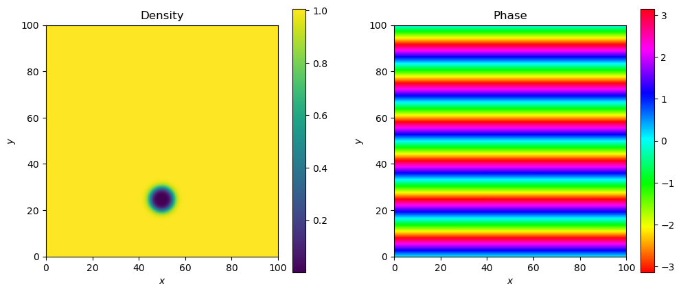

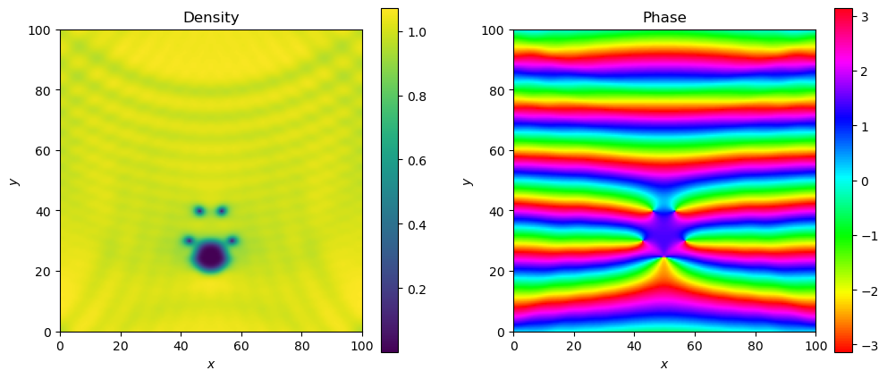

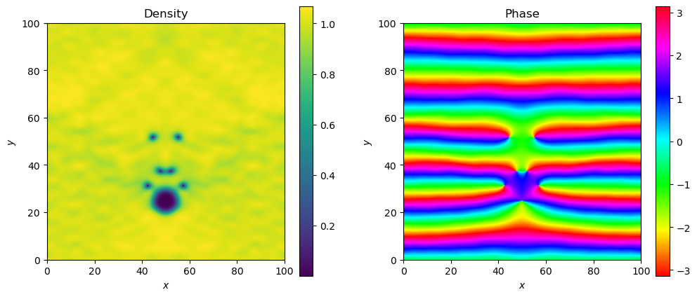

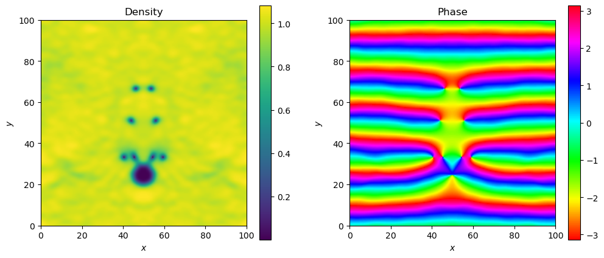

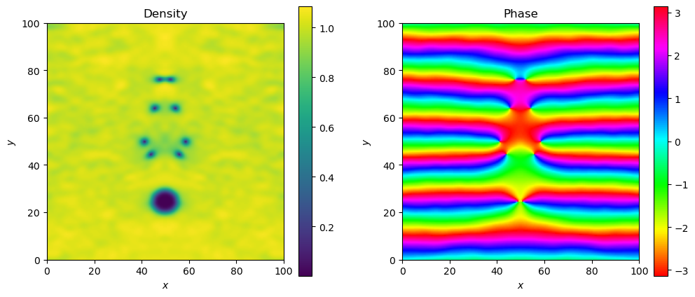

```python
L_x = 100; N_x = 200; d=L_x/N_x
L_y = 100; N_y = int(N_x/L_x * L_y)
T=200; N_t = 4000

x = np.outer(np.linspace(d, L_x, N_x), np.ones(N_y))
y = np.outer(np.ones(N_x), np.linspace(d, L_y, N_y))


V = np.zeros((N_t,N_x,N_y))
V[:]=10*np.exp(-((x-L_x/4)**2+(y-L_y/2)**2)/10)

f_0=np.ones((N_x,N_y))
phase_0=2*np.pi*x/L_x*6

f= run_simulation(
    L_x, N_x, L_y, T, N_t,
    V, f_0,
    iT=20, phase_0=phase_0
)
```

```python
"""Animate!"""
N_frames=100
animate_dens_phase(np.abs(np.array([f[int(N_t/N_frames)*i] for i in range(N_frames)])),
                   np.array([np.angle(f[int(N_t/N_frames)*i]) for i in range(N_frames)]),
                   'vortex shedding.gif', [0, L_x, 0, L_y], fps=100)
```